# Three Sentiment Models

## Setup

### Imports

```python
import pandas as pd
import numpy as np
from IPython.display import Markdown as md
import matplotlib.pyplot as plt
import os

from gensim.parsing.preprocessing import remove_stopwords
from gensim import corpora
from gensim import models
from gensim.utils import tokenize
from gensim.parsing.porter import PorterStemmer

from textblob import TextBlob
```

### Run Settings

```python
# run from parent directory
os.chdir('../')
```

### Display Configuration

```python
pd.set_option('display.max_columns', None)
pd.set_option('display.max_rows', 100)
plt.style.use('seaborn')
plt.rcParams['figure.figsize'] = [14, 10]
plt.rcParams['figure.dpi']
```

```
72.0
```

## Load Research Data

```python
call_meta = pd.read_csv('./output/r500_call_meta.csv')
call_text_statements = pd.read_csv('./output/r500_call_text.csv')

call_text = call_text_statements.loc[:, ['cid', 'text']].groupby(['cid'])['text'].apply(
    lambda x: ''.join(x)).reset_index()
# call_data = call_meta.merge(call_text,how='inner',on='cid')
```

### Explore Calls

Structured data -- text alongside financial data -- allows for fine-tuned exploration. As the data set grows, Text-Indexing tools like Elastic Search / SOLR are much better suited for these types of queries.

In the **Answers section**, when has **Tim Cook** mentioned **China** and **Trade** (in the same statement) and what did he say?

```python
pd.set_option('display.max_colwidth', 400)
call_text_statements.loc[(call_text_statements['ticker']=='AAPL') & \
              (call_text_statements['statement_type'] == 'A') & \
              (call_text_statements['role'].str.lower().str.contains('chief')) & \
              (call_text_statements['text'].str.lower().str.contains('china')) & \
              (call_text_statements['text'].str.lower().str.contains('trade')) \
              ,['ticker','call_date','text']]
```

[output not shown]

Which Consumer Discretionaries are mentioning gaming?

```python
call_text_statements.loc[(call_text_statements['sector']=='Consumer Discretionary') & \
              (call_text_statements['text'].str.lower().str.contains('gaming')) \
              ,['ticker','call_date','text']]
```

|  | ticker | call_date | text |
| --- | --- | --- | --- |
| 1151 | BBY | 2018-08-28 | Good morning, everyone. Before I talk about our second quarter results versus last year, I would like to talk about them versus the expectations we shared with you last quarter. On enterprise revenue … |
| 1160 | BBY | 2018-08-28 | Thank you, Matt. To be clear, we continue to be very excited by online and all of the digital capabilities we are building for our customers. When I see how we've evolved over the last 5 or 6 years, w… |
| 1163 | BBY | 2018-08-28 | Yeah, so what we saw there was a little bit unexpected strength in gaming. A couple facets on that. One, as we've talked about before, we tend to over-index on gaming consoles. That is where we saw so… |
| 1177 | BBY | 2018-08-28 | Yeah, so based on the comp deltas that we're seeing -- and remember, you have the 53rd week in Q4, so it gets a little tricky -- the guide would imply a comp of basically flat to up 3%, somewhere in t… |
| 4156 | BBY | 2018-11-20 | Good morning, everyone, and thank you for joining us. We'll begin today with a review of our third quarter performance, provide updates on our progress as we implement our Best Buy 2020: Building the … |
| 4157 | BBY | 2018-11-20 | Good morning, everyone. Before I talk about our third quarter results versus last year, I would like to talk about them versus the expectations we shared with you last quarter. Enterprise revenue of $… |
| 4180 | BBY | 2018-11-20 | Yes. There are such amazing sets of exciting products for the holiday That's one of the things that makes us excited about this category, which is the continued flow innovation, and what's great about… |
| 13754 | LVS | 2019-04-17 | Well, Joe if you look in your deck page, turn to page 11, I think it's the nicest slide I've seen in a long time. It illustrates our growth in both base mass and premium mass and the numbers are just … |
| 13760 | LVS | 2019-04-17 | Okay. Let's take a crack at this. MBS has been an extraordinary story, which is altered by an outstanding government and the visionary Company and Founder. It's one of the greatest development stories… |
| 13773 | LVS | 2019-04-17 | Great. Thanks for that. And then it is nothing but a follow-up to an earlier question, just on the overall market growth you saw on premium mass. Can you just give us your latest thoughts on kind of t… |
| 13776 | LVS | 2019-04-17 | We'd like to comp them all, Shaun but we don't have the demand yet. We are 55% I believe, portfoliowide. The truth is I mean that's -- you cannot get a -- there is no customer in the world that pays k… |
| 13783 | LVS | 2019-04-17 | Well, obviously we're different than some other people in Vegas, first, we have a different campus. And I think that we're structurally different and when Sheldon built this place, we're the only peop… |
| 13790 | LVS | 2019-04-17 | Thanks and good morning. My first question is on the Marina Bay Sands. Could you comment a little bit on the timelines of when you expect the project to be able to open? And also could you give us som… |
| 13792 | LVS | 2019-04-17 | The Gaming piece. |
| 13793 | LVS | 2019-04-17 | The Gaming Piece, sorry, excuse me. The gaming piece. So all of the benefits associated with this development that we may receive are dependent on us achieving certain milestones. So this is something… |
| 13814 | LVS | 2019-04-17 | One thing I would add to Patrick's comments, David to answer your question by local versus foreign it's clear when you build a 1,000 square foot suites and you build this kind of arena you're focusing… |
| 40277 | BBY | 2019-05-23 | Good morning, everyone. I am deeply grateful to Hubert and the rest of the Board of Directors for their confidence in me and their clear belief that this leadership evolution is in the best interest o… |
| 50938 | LVS | 2019-07-24 | Thanks Felicia and apologies for Dan's font. I show you pain. Let's put base mass and premium mass segments in perspective. Our drop in the second quarter, I think it was about $6.1 billion that was u… |
| 50940 | LVS | 2019-07-24 | I think to that point, we -- again we'll be real clear about this. Our success this quarter is at 14% year-on-year growth in base mass shows the power of these products we have currently in the market… |
| 50948 | LVS | 2019-07-24 | Sure. We're very proud about Vegas performance. I think it's the best in our history or if not as close to it. Everything worked in this quarter, from a gaming and lodging perspective, the rates were … |
| 50956 | LVS | 2019-07-24 | That's not really something that we -- that we put out publicly. Just in terms of the way to compare it with that -- with that break down. So I think just in general, you should look at the win for gu… |
| 50984 | LVS | 2019-07-24 | We currently don't have any information and we're eagerly awaiting what we should do. But that being said, we're very proud of the investment that our Chairman made when we first started building in M… |
| 50985 | LVS | 2019-07-24 | I guess one of one of the other concession holders has talked about big non-gaming investment that may be added to the resort, not necessarily anything that would have to be added before a concession … |
| 50986 | LVS | 2019-07-24 | Hi, Robin, it's Rob. I think about it every day. I would like to invest with both hands in non-gaming assets because I think if you look at our history, we've done it without being really -- when they… |
| 50989 | LVS | 2019-07-24 | Good question, Justin [Phonetic]. Good question. Well, the first question you asked about the time play. I don't think that's worth worrying about. We don't see any evidence of that, if anything in th… |
| 73014 | BBY | 2019-08-29 | Good morning, everyone, and thank you for joining us. Today, we reported $9.54 billion in revenue, expanded our non-GAAP operating income rate by 20 basis points and delivered non-GAAP diluted earning… |
| 73015 | BBY | 2019-08-29 | Thanks, Corie. Good morning, and hello, everyone. It's a huge honor to be given the opportunity to help lead this company forward as CFO. We have made tremendous progress in how we enrich people's liv… |
| 73022 | BBY | 2019-08-29 | Yes, thanks for the question. So, for guidance purposes, I think what we're looking at for the rest of this year, one of the thing that sequentially changes from the first part of this year is a littl… |
| 73027 | BBY | 2019-08-29 | Okay. Fair enough. And then separately maybe looking out to next year and contemplating some near-term headwinds around gaming and mobile, I was hoping you could talk about some of the technology inno… |
| 73028 | BBY | 2019-08-29 | Hey, Peter, it's Mike. Thanks for the question. It might be a little too early to give you specifics on those categories, but we're excited about all of them. And I think about what Corie talked about… |
| 73031 | BBY | 2019-08-29 | Thanks. Good morning, everybody. So I wanted to follow up on the guidance question a little bit more. So just think about it, the -- you'd be at about $0.27 year-to-date, you guided up 3Q about $0.08,… |
| 73053 | BBY | 2019-08-29 | No, I would definitely not characterize us as seeing anything that gives concern today. I mean, I think, we're very pleased with an almost 2% comp domestically here in Q2. We're seeing good buying beh… |
| 73054 | BBY | 2019-08-29 | And so that's a sort of a perfect segue into my follow-up here, right. You think about sort of your initial outlooks for certain product category growth in 2020, right, whether it's an acceleration in… |
| 73057 | BBY | 2019-08-29 | Good morning. Thanks very much for taking my questions. Maybe just a little more specificity, if you could on gaming, and why you think, I guess, the second half of the year, might be a little bit tou… |
| 73058 | BBY | 2019-08-29 | Yes, Curt, the gaming cycle is well known, and as the year is progressed, what we've seen is there's more visibility to a couple of new platforms that have yet to be announced, but are well regarded a… |
| 73064 | BBY | 2019-08-29 | No. The overall top line, I think, like we said, we see categories come up and down, like we always do. As we look at this point in the year, gaming is -- like we said is the biggest sequential drag a… |
| 81846 | LVS | 2019-10-23 | Thank you Dan, and good afternoon everyone. As you all know, I've missed our earnings conference call these last few quarters. So, let me begin by saying I feel good, I'm very happy to be here with Ro… |
| 81848 | LVS | 2019-10-23 | Yeah, nice surprise. So, as you know, I mean Macao is the world's largest gaming market and the current, future growth of that market is predicated on the mass market. If you look at page 16 in the de… |
| 81850 | LVS | 2019-10-23 | I think there is going to be disruption, but your reference point is spot on. I think, we can capture if the team does their job, capture some of that disruption or region in Four Seasons Indonesian [… |
| 81854 | LVS | 2019-10-23 | In Macao, as you know Thomas is the mass segment that drives growth, it's that simple. In this challenging macro environment, we just continue to see it, grow and grow and that business revolves aroun… |
| 81878 | LVS | 2019-10-23 | Not a specific answer for September. But, I will tell you that we are focusing on getting more of this mass and premium mass business in our building again with 7000 plus accommodations, we should be … |
| 81891 | LVS | 2019-10-23 | Shaun, that thing's referenced page 19 ongoing strategic reinvestment. Page 19 gives you a great snapshot of our timing on this thing. You're right, we had a little delay in some of the issues in the … |
| 103927 | BBY | 2019-11-26 | Good morning, everyone, and thank you for joining us. Today we reported $9.76 billion in revenue, expanded our non-GAAP operating income rate by 70 basis points and delivered non-GAAP diluted earnings… |
| 103928 | BBY | 2019-11-26 | Good morning, and hello everyone. Before I talk about our third quarter results versus last year, I would like to talk about them versus the expectations we shared with you last quarter.On enterprise … |
| 103930 | BBY | 2019-11-26 | Sure. This is Matt. I'll take that question. First, in terms of the revenue guidance range, I think I would say, holiday is always a special season for consumer electronics. Pricing convenience is ver… |
| 103965 | BBY | 2019-11-26 | Hey guys. Thanks for taking my questions. So one was a thought about, as we think about next year, it looks like you guys are putting a pretty strong comps even though there's really not a product cyc… |
| 103972 | BBY | 2019-11-26 | Got it. Thanks Corie. And then on the gaming category weakness, curious if you could expand on that in a little more detail, whether you think it's primary -- primarily innovation driven or if there's… |
| 103973 | BBY | 2019-11-26 | Hey, Zach, it's Mike. I think the gaming category still is exciting. We think about it more broadly than just the console category based on what we think and where consumers are looking for experience… |
| 113482 | LVS | 2020-01-29 | Thank you, Dan. Good afternoon, everyone, and thank you for joining us today. We had a great quarter and a great year across all our markets. Companywide adjusted property EBITDA for the fourth quarte… |
| 113489 | LVS | 2020-01-29 | Yeah. So let's break it apart. A great base mass quarter ending up at almost 9%, 8.9%, or something like that. So base mass, we were -- I think our strongest base mass performance on our history, whic… |
| 113491 | LVS | 2020-01-29 | No, I just think you're seeing a shift to more non -- I mean, our business as you know is driven by, we have a gaming to follow up [Phonetic], but the non-gaming is powerful. If we can make $0.5 billi… |
| 113525 | LVS | 2020-01-29 | We -- Shaun, we don't -- I'll say this. We have been there for what 18 years, 19 years and I think Sheldon's contribution, this Company's contribution as the biggest investor in Macao speaks for itsel… |
| 113527 | LVS | 2020-01-29 | Yeah. I mean, Sheldon has been very vocal about his willingness to invest heavily. We've spoken [Technical Issues] over the years about that. There is no surprise that we feel. And as the authors of t… |
| 124289 | YUM | 2020-02-06 | Thank you, Keith, and good morning, everyone. 2019 was a truly historic year for Yum!. First, we successfully completed our three-year transformation and delivered on our bold commitment. Second, we s… |
| 134280 | BBY | 2020-02-27 | Good morning, everyone, and thank you for joining us. Today, we are excited to report strong Q4 results with revenue of $15.2 billion and non-GAAP earnings per share of $2.90. Our enterprise comparabl… |
| 134281 | BBY | 2020-02-27 | Good morning. Before I talk about our fourth quarter results versus last year, I would like to talk about them versus the expectations we shared with you last quarter. On Enterprise revenue of $15.2 b… |
| 134283 | BBY | 2020-02-27 | Sure. This is Matt. I'll start with that. First, as arcs remarks, I believe we're operating in a very positive consumer environment similar to last year. All the data points indicate a good consumer a… |
| 134327 | BBY | 2020-02-27 | We are growing our toy assortment rate, but it is not a meaningful business for us. And I don't think it will be. We look at toys as a nice color to our gaming business. And while traditional gaming h… |
| 134328 | BBY | 2020-02-27 | I think the wonderful thing is the vast majority of our assortment is now being at toys by kids. When you think about iPads, when you think about computing gaming, I mean toys for us is such a bigger … |
| 135673 | TGT | 2020-03-03 | Thanks. Good morning, and thanks for hosting this. So I have two questions. First, a bit of retrospective on the fourth quarter, how much do you think there were some industry factors that went on the… |
| 143435 | LVS | 2020-04-22 | Hey, Joe, it's Patrick. Thanks for the question. I think if you look back at our margin over the last couple of years as the premium mass and mass business grew, those margin areas are probably approp… |
| 143445 | LVS | 2020-04-22 | So, kind of a two-part question there. I appreciate the detail. I think the way to think about margin recovery is that when you look at sort of call it our uncontrolled operating expenses, call it acr… |
| 143448 | LVS | 2020-04-22 | Thank you, Patrick. We will reinstate the dividend after discussing with our Board of Directors. When things get back to where we were, it's very simple, I don't think it's a longtime away. If the rum… |
| 143467 | LVS | 2020-04-22 | Yeah. While currently as you know, the customer mix there is zero, since we're closed till June 1. The team is pretty confident that we'll get open in June. Doesn't very much concerned that it would b… |
| 143479 | LVS | 2020-04-22 | Hey. Thank you, and thanks everyone for the comments. I think this was probably best for you as you think about kind of the near to medium-term, and maybe make the assumption that specifically in Maca… |
| 143496 | LVS | 2020-04-22 | Listen, we -- Macao is -- will be the best if not one of the best. It will be the best and the best gaming and leisure destination anywhere in the world. So there is no reason why it shouldn't grow. W… |
| 143502 | LVS | 2020-04-22 | Hi. Evening, everyone and thanks for taking my question. I wanted to just go back to the reopening and try and envision. And Rob, you touched on this on the mass side. What operationally it could look… |
| 149707 | AMZN | 2020-04-30 | Sure, well, we're happy with the growth in Q1 on such a large base, again, we're -- now it's a $41 billion run rate and that's grown 33% year-over-year, but what we're seeing kind of post-COVID is it … |
| 171344 | CMG | 2020-07-22 | Thanks, Ashish, and good afternoon everyone. Since our last earnings call, the world has continued to face unprecedented challenges with regard to health, economic and social issues. However, I'm so p… |
| 172306 | LVS | 2020-07-22 | So there's a couple of things here. Some of it's related to permitting, but I think the key thing is we've completed the Grand Suites at Four Seasons. So that's done, right? The Londoner hotel, which … |
| 172318 | LVS | 2020-07-22 | So just one comment on the margin structure. If you think about the run rate business prior to COVID, more than 60% in Macao of our expenses were really variable, gaming taxes and sort of things relat… |
| 172323 | LVS | 2020-07-22 | I think we've worked very well with our -- Thomas, to your point, our retail portfolio is a very important part of the mix of our business. We remain believers in that will come back in a big way in A… |
| 172326 | LVS | 2020-07-22 | There's still things on the books. We see Singapore as a starting point. We are seeing demand in Singapore, but I think people are very tentative about committing. There is inquiries.There's definitel… |
| 172331 | LVS | 2020-07-22 | The regulations that were promulgated by the Japanese government that went through the Diet were not conducive to attracting the kind of investment that it requires. The cost of construction and the c… |
| 172333 | LVS | 2020-07-22 | We need more, more customers, and we need lots more. The truth is the hotels running in this town, mid-week, 20%, 25%, 30%; weekends, 50%, 60%. That doesn't work. They're only coming basically from dr… |
| 181780 | AMZN | 2020-07-30 | Yeah. Let me start with that second one. Thanks, Doug. So in the AWS segment revenue, what we see are companies are working really hard right now to cut expenses, especially in the more challenged bus… |
| 191825 | TGT | 2020-08-19 | Thanks, John, and good morning, everyone. Today, we're sharing second-quarter results that are, by virtually any measure, exceptional. But I want to say at the outset that what's most extraordinary of… |

```python
pd.set_option('display.max_colwidth', 100)
```

## Sentiment Model #1 (The OG): The Loughran & Mcdonald Financial Dictionary

### Pre-Process Conference Call Text

Tokenize and remove punctuation

```python
call_text_lm = call_text.copy()

call_text_lm['text'] = call_text_lm['text'].apply(lambda x: [w for w in tokenize(x, deacc=True)])
call_text_lm['text'][0][0:10]
```

```
['Thank',
 'you',
 'Good',
 'afternoon',
 'everyone',
 'and',
 'welcome',
 'to',
 'NVIDIA',
 's']
```

Clean: Remove Stop Words, Upper-Case Words, and Abnormally Short/Long Words

```python
call_text_lm['text'] = call_text_lm['text'].apply(lambda x: [remove_stopwords(w) for w in x])
call_text_lm['text'] = call_text_lm['text'].apply(lambda x: [w for w in x
                                               if (2 < len(w) < 15) and (w.islower())])
call_text_lm['text'][0][0:10]
```

```
['afternoon',
 'welcome',
 'conference',
 'quarter',
 'fiscal',
 'today',
 'like',
 'remind',
 'webcast',
 'live']
```

Porter Stemming

```python
# stemming (porter)
p = PorterStemmer()
call_text_lm['text'] = call_text_lm['text'].apply(lambda x: p.stem_documents(x))
call_text_lm['text'][0][0:10]
```

```
['afternoon',
 'welcom',
 'confer',
 'quarter',
 'fiscal',
 'todai',
 'like',
 'remind',
 'webcast',
 'live']
```

Bag of Words Transformation

```python
# create dictionary object
dictionary = corpora.Dictionary(call_text_lm['text'])

# filter extremes
# dictionary.filter_extremes(no_below=2, no_above=0.5)

# bag-of-words transformation
corpus = [dictionary.doc2bow(text) for text in call_text_lm['text']]
```

### Load and Stem Dictionaries

```python
pos_list = pd.read_csv('./model_inputs/lm_word_lists/lm_positive.csv', header=None)[0].str.lower().to_list()
neg_list = pd.read_csv('./model_inputs/lm_word_lists/lm_negative.csv', header=None)[0].str.lower().to_list()
pos_neg = pos_list + neg_list

pos_stemmed = list(set(p.stem_documents(pos_list)))
neg_stemmed = list(set(p.stem_documents(neg_list)))
```

```python
pos_list[0:20]
```

```
['able',
 'abundance',
 'abundant',
 'acclaimed',
 'accomplish',
 'accomplished',
 'accomplishes',
 'accomplishing',
 'accomplishment',
 'accomplishments',
 'achieve',
 'achieved',
 'achievement',
 'achievements',
 'achieves',
 'achieving',
 'adequately',
 'advancement',
 'advancements',
 'advances']
```

```python
neg_list[0:20]
```

```
['abandon',
 'abandoned',
 'abandoning',
 'abandonment',
 'abandonments',
 'abandons',
 'abdicated',
 'abdicates',
 'abdicating',
 'abdication',
 'abdications',
 'aberrant',
 'aberration',
 'aberrational',
 'aberrations',
 'abetting',
 'abnormal',
 'abnormalities',
 'abnormality',
 'abnormally']
```

### L&M Raw Word Counting Method

**Positive Sentiment**: Positive words in a call / total words in call

**Negative Sentiment**: Negative words in a call / total words in call

**Overall Sentiment**: Positive Sentiment - Negative Sentiment

```python
word_cf = [[(dictionary[id], count) for id, count in line] for line in corpus]

# calculate count frequency sentiment
sent_cf = []
for call in word_cf:
    word_count = sum([cf for tkn, cf in call])
    pos = 0; neg = 0

    if word_count > 0:
        pos = sum([cf for tkn, cf in call if tkn in pos_stemmed]) / word_count
        neg = sum([cf for tkn, cf in call if tkn in neg_stemmed]) / word_count

    sent_cf.append({'pos_cf': pos,
                    'neg_cf': neg,
                    'sent_cf': pos - neg})
```

```python
sent_cf[0:5]
```

```
[{'pos_cf': 0.048470264695771745,
  'neg_cf': 0.011687865245788931,
  'sent_cf': 0.036782399449982815},
 {'pos_cf': 0.06846673095467695,
  'neg_cf': 0.01800064288010286,
  'sent_cf': 0.05046608807457409},
 {'pos_cf': 0.058530510585305104,
  'neg_cf': 0.016604400166044003,
  'sent_cf': 0.0419261104192611},
 {'pos_cf': 0.06228172293364377,
  'neg_cf': 0.012805587892898719,
  'sent_cf': 0.04947613504074505},
 {'pos_cf': 0.050268732216250396,
  'neg_cf': 0.016756244072083464,
  'sent_cf': 0.033512488144166935}]
```

### L&M TF-IDF Method

**TF-IDF**: Words that appear across many documents (document frequency) are downweighted.

This is recommended (over raw counts) in nearly all use-cases, *but is it right for this context?*

```python
# tfidf transformation
tfidf = models.TfidfModel(corpus)  # fit model
corpus_tfidf = tfidf[corpus]  # apply model

# count words per call
word_tfidf = [[(dictionary[id], count) for id, count in line] for line in corpus_tfidf]

# calculate tfidf sentiment
sent_tfidf = []
for call in word_tfidf:
    pos = sum([tfidf for tkn, tfidf in call if tkn in pos_stemmed])
    neg = sum([tfidf for tkn, tfidf in call if tkn in neg_stemmed])

    safe_div0 = (pos + neg) > 0

    sent_tfidf.append({'pos_tfidf': (pos / (pos + neg)) if safe_div0 else 0,
                       'neg_tfidf': (neg / (pos + neg)) if safe_div0 else 0,
                       'sent_tfidf': ((pos - neg) / (pos + neg)) if safe_div0 else 0})
```

```python
sent_tfidf[0:5]
```

```
[{'pos_tfidf': 0.6422305555710988,
  'neg_tfidf': 0.35776944442890113,
  'sent_tfidf': 0.2844611111421976},
 {'pos_tfidf': 0.5038344075424612,
  'neg_tfidf': 0.4961655924575387,
  'sent_tfidf': 0.007668815084922535},
 {'pos_tfidf': 0.6381958393463683,
  'neg_tfidf': 0.36180416065363175,
  'sent_tfidf': 0.27639167869273645},
 {'pos_tfidf': 0.5649472622924031,
  'neg_tfidf': 0.4350527377075968,
  'sent_tfidf': 0.12989452458480633},
 {'pos_tfidf': 0.5683290413380063,
  'neg_tfidf': 0.4316709586619937,
  'sent_tfidf': 0.13665808267601268}]
```

### Frequency Analysis

```python
agg_word_freq = {dictionary[k]: v for k, v in dictionary.cfs.items()}
agg_word_freq = pd.DataFrame({'token': agg_word_freq.keys(), 'cf': agg_word_freq.values()})

agg_doc_freq = {dictionary[k]: v for k, v in dictionary.dfs.items()}
agg_doc_freq = pd.DataFrame({'token': agg_doc_freq.keys(), 'df': agg_doc_freq.values()})

agg_freq = agg_word_freq.merge(agg_doc_freq, on='token')
agg_freq.sort_values(by='cf', ascending=False, inplace=True)
```

```python
agg_freq
```

|  | token | cf | df |
| --- | --- | --- | --- |
| 74 | year | 177770 | 2790 |
| 3 | quarter | 144531 | 2790 |
| 386 | think | 127067 | 2788 |
| 44 | busi | 86434 | 2784 |
| 65 | growth | 84212 | 2781 |
| ... | ... | ... | ... |
| 12871 | watercolor | 1 | 1 |
| 12870 | pastel | 1 | 1 |
| 12868 | speediest | 1 | 1 |
| 12867 | smidgen | 1 | 1 |
| 17107 | embryonari | 1 | 1 |

17108 rows × 3 columns

#### Most commonly mentioned positive words:

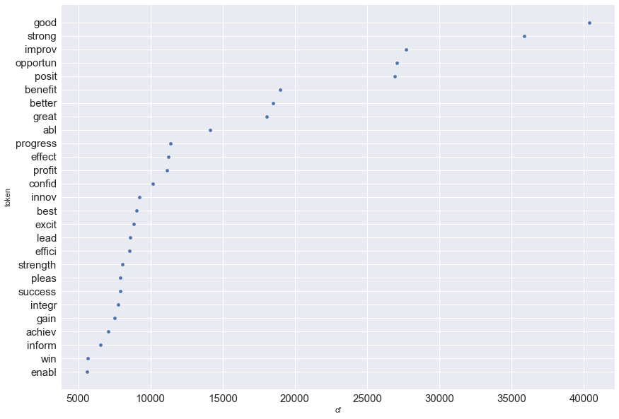

```python
agg_freq.loc[(agg_freq['token'].isin(pos_stemmed)) & (agg_freq['cf']>5000),
             ['token','cf']].plot.scatter(x='cf',y='token',fontsize=15).invert_yaxis()
```

#### Most commonly mentioned negative words

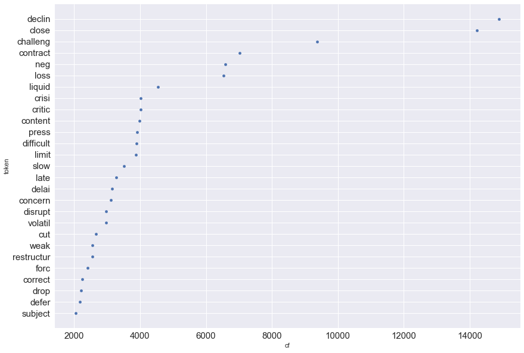

```python
agg_freq.loc[(agg_freq['token'].isin(neg_stemmed)) & (agg_freq['cf']>2000),
             ['token','cf']].plot.scatter(x='cf',y='token',fontsize=15).invert_yaxis()
```

## Sentiment Model #2 (Popular Off-the-Shelf): TextBlob Sentiment Score ("off-the-shelf")

Many First Pass Sentiment Tests (in a variety of fields) come from "out of the box" solutions that are extremely easy to implement. Python has a variety of libraries for this.

Here we use `TextBlob`. One line of code and we're done...*But is it the right tool for the job?*

`TextBlob`'s sentiment model uses Naive Bayes, trained on Movie Reviews (this may be a problem for financial context).

### Overview

```python
# calc text blob sentiment
calls_textblob = pd.DataFrame({'cid': call_text['cid'],
                               'sent_tb': call_text['text'].apply(lambda x: TextBlob(x).sentiment.polarity)
                               }).set_index('cid')
```

```python
calls_textblob.sort_values(by='sent_tb',ascending=False).head(10)
```

| cid | sent_tb |
| --- | --- |
| 2020-04-21-paccar-inc-pcar-q1-2020-earnings-call-transcript | 0.251072 |
| 2020-02-25-salesforcecom-inc-crm-q4-2020-earnings-call-transc | 0.243713 |
| 2020-01-30-service-now-now-q4-2019-earnings-call-transcript | 0.241541 |
| 2020-02-05-chipotle-mexican-grill-inc-cmg-q4-2019-earnings-ca | 0.235127 |
| 2019-05-09-etsy-inc-etsy-q1-2019-earnings-call-transcript | 0.232961 |
| 2019-03-04-salesforcecom-inc-crm-q4-2019-earnings-conference | 0.229787 |
| 2019-04-17-las-vegas-sands-corp-lvs-q1-2019-earnings-call-tra | 0.228934 |
| 2020-07-30-service-now-now-q2-2020-earnings-call-transcript | 0.226763 |
| 2019-04-30-chegg-chgg-q1-2019-earnings-call-transcript | 0.225628 |
| 2019-10-24-service-now-now-q3-2019-earnings-call-transcript | 0.225272 |

```python
calls_textblob.sort_values(by='sent_tb',ascending=True).head(10)
```

| cid | sent_tb |
| --- | --- |
| 2019-08-08-monster-beverage-corp-mnst-q2-2019-earnings-call-t | 0.029989 |
| 2020-08-05-monster-beverage-corp-mnst-q2-2020-earnings-call-t | 0.049518 |
| 2019-11-08-monster-beverage-corp-mnst-q3-2019-earnings-call-t | 0.050481 |
| 2020-07-28-omnicom-group-inc-omc-q2-2020-earnings-call-transc | 0.056745 |
| 2020-07-14-jpmorgan-chase-co-jpm-q2-2020-earnings-call-transc | 0.058756 |
| 2020-01-23-mt-bank-corporation-mtb-q4-2019-earnings-call-tran | 0.059167 |
| 2019-03-07-costco-wholesale-corporation-cost-q2-2019-earnings | 0.061135 |
| 2020-07-14-jpmorgan-chase-jpm-q2-2020-earnings-call-transcrip | 0.063806 |
| 2020-07-28-edison-international-eix-q2-2020-earnings-call-tra | 0.064401 |
| 2020-04-20-lennox-international-inc-lii-q1-2020-earnings-call | 0.070548 |

## Sentiment Model #3 (Latest & Greatest): Google's BERT Sequence Classifier

write out to file for finBert sentiment analysis

```
output = []
for i, row in call_text_statements.iterrows():
    this_output = pd.DataFrame({'sentence': split_sentences(row['text'])})
    this_output['cid'] = row['cid']
    this_output['statement_num'] = row['statement_num']
    this_output = this_output[['cid', 'statement_num', 'sentence']]
    output.append(this_output)
output_df = pd.concat(output)
output_df.to_csv('./output/r500_sentences.csv', index=False)
output_df['sentence'].to_csv('./output/r500_sentences_text_only.csv', sep='\n', index=False, header=False,
                             quoting=csv.QUOTE_NONE)
```

run process in different virutal environment

```
conda activate finbert
(finbert) finbert_dir> python predict.py --text_path R500_sentences_text_only.csv --output_dir output/ --model_path models/sentiment/sentiment.tar.gz
```

### Sentiment Model Trained on Financial PhraseBank

```python
# read classified finBert Sentences from output
sent_classified = pd.read_csv('./output/r1000_sentences_classified.csv')
sent_map = pd.read_csv('./output/r1000_sentences.csv')
sent_finBert = sent_map[['cid', 'statement_num']].join(sent_classified)
```

```python
sent_classified[0:10]
```

[output not shown]

```python
def calc_call_sentiment(predictions):
    sent_count = len(predictions)
    pos = predictions[predictions == 'positive'].count()
    neg = predictions[predictions == 'negative'].count()
    return pd.Series({'finBert_pos': pos / sent_count,
                      'finBert_neg': neg / sent_count,
                      'finBert_sent': (pos - neg) / sent_count
                      })


# take mean from sentences into one score per call
calls_sent_finBert = sent_finBert.groupby(['cid']).apply(lambda x: calc_call_sentiment(x['prediction']))
calls_sent_finBert['finBert_sent_mean'] = sent_finBert.groupby(['cid'])['sentiment_score'].mean()
```

```python
calls_sent_finBert.sort_values(by='finBert_sent',ascending=False)[0:10]
```

| cid | finBert_pos | finBert_neg | finBert_sent | finBert_sent_mean |
| --- | --- | --- | --- | --- |
| 2019-08-22-salesforcecom-inc-crm-q2-2020-earnings-call-transc | 0.539267 | 0.044503 | 0.494764 | 0.446257 |
| 2019-10-15-first-republic-bank-frc-q3-2019-earnings-call-tran | 0.500000 | 0.016026 | 0.483974 | 0.443844 |
| 2020-05-07-ansys-anss-q1-2020-earnings-call-transcript | 0.503425 | 0.037671 | 0.465753 | 0.406401 |
| 2019-07-30-perkinelmer-inc-pki-q2-2019-earnings-call-transcri | 0.468828 | 0.012469 | 0.456359 | 0.420118 |
| 2019-02-06-atmos-energy-ato-q1-2019-earnings-conference-call | 0.481675 | 0.031414 | 0.450262 | 0.416682 |
| 2020-08-06-ceridian-hcm-holding-inc-cday-q2-2020-earnings-cal | 0.446154 | 0.000000 | 0.446154 | 0.400450 |
| 2019-04-25-american-electric-power-company-inc-aep-q1-2019-ea | 0.466418 | 0.022388 | 0.444030 | 0.409749 |
| 2020-03-19-cintas-corp-ctas-q3-2020-earnings-call-transcript | 0.472669 | 0.028939 | 0.443730 | 0.386836 |
| 2020-01-30-valero-energy-corp-vlo-q4-2019-earnings-call-trans | 0.482143 | 0.049107 | 0.433036 | 0.390028 |
| 2019-10-31-clorox-co-clx-q1-2020-earnings-call-transcript | 0.457399 | 0.029148 | 0.428251 | 0.392579 |

Most Negative Calls:

```python
calls_sent_finBert.sort_values(by='finBert_sent',ascending=True)[0:10]
```

| cid | finBert_pos | finBert_neg | finBert_sent | finBert_sent_mean |
| --- | --- | --- | --- | --- |
| 2020-02-05-dte-energy-co-dte-q4-2019-earnings-call-transcript | 0.193939 | 0.303030 | -0.109091 | -0.061258 |
| 2020-04-22-chubb-cb-q1-2020-earnings-call-transcript | 0.100000 | 0.186364 | -0.086364 | -0.029466 |
| 2020-08-03-jacobs-engineering-group-inc-j-q3-2020-earnings-ca | 0.148707 | 0.232759 | -0.084052 | -0.038434 |
| 2020-03-12-broadcom-inc-avgo-q1-2020-earnings-call-transcript | 0.156863 | 0.176471 | -0.019608 | 0.036027 |
| 2020-04-22-lam-research-corp-lrcx-q3-2020-earnings-call-trans | 0.118750 | 0.135417 | -0.016667 | 0.037732 |
| 2019-11-07-cardinal-health-inc-cah-q1-2020-earnings-call-tran | 0.178295 | 0.186047 | -0.007752 | 0.024364 |
| 2020-08-04-williams-companies-inc-wmb-q2-2020-earnings-call-t | 0.141907 | 0.148559 | -0.006652 | 0.028899 |
| 2020-05-20-analog-devices-inc-adi-q2-2020-earnings-call-trans | 0.097792 | 0.104101 | -0.006309 | 0.030351 |
| 2020-05-12-novavax-nvax-q1-2020-earnings-call-transcript | 0.084746 | 0.080508 | 0.004237 | 0.056021 |
| 2020-04-30-amazoncom-inc-amzn-q1-2020-earnings-call-transcrip | 0.312821 | 0.307692 | 0.005128 | -0.002277 |